# Администрирование системных подсистем

Настройка сервера и клиента NFSv4

Сейдалиев Тагиетдин Ровшенович

Российский университет дружбы народов, Москва, Россия

08 декабря 2025

# Цель работы

## Основная цель

Приобрести навыки настройки сервера NFSv4, включая работу с SELinux, firewall, bind-монтированием и автоматическим подключением ресурсов на клиенте.

# Настройка сервера

## Установка и подготовка окружения

- Установка `nfs-utils`
- Создание корневого каталога `/srv/nfs`
- Настройка доступа в `/etc/exports`

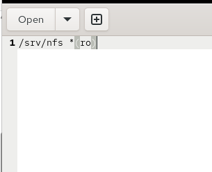

Экспорт каталога /srv/nfs

## Настройка SELinux и запуск NFS

- Назначение контекста `nfs_t`
- Применение `restorecon`
- Запуск и автозагрузка `nfs-server.service`
- Разрешение сервиса `nfs` в firewall

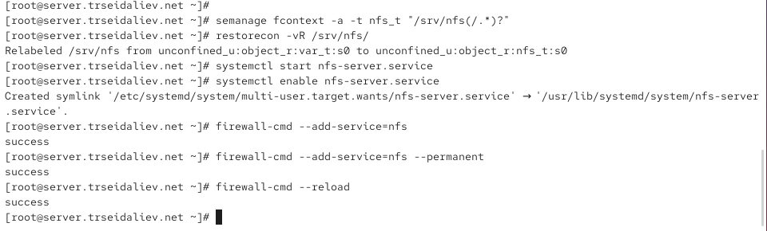

SELinux и запуск NFS

# Проверка работы клиента

## Ошибка при первом подключении

`showmount` → ошибка RPC из-за заблокированных служб `rpcbind` и `mountd`.

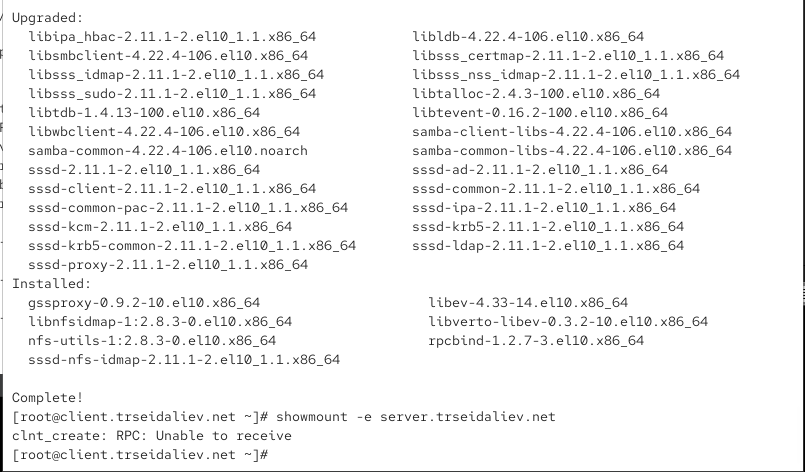

Ошибка showmount

## Проверка после отключения firewall

Firewall отключён → `showmount` успешно отображает экспортируемые каталоги.

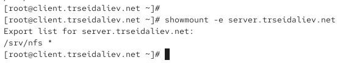

Успешный showmount

# Настройка firewall

## Анализ используемых портов

Службы, необходимые для работы NFS:

- `nfs`
- `rpc-bind`
- `mountd`

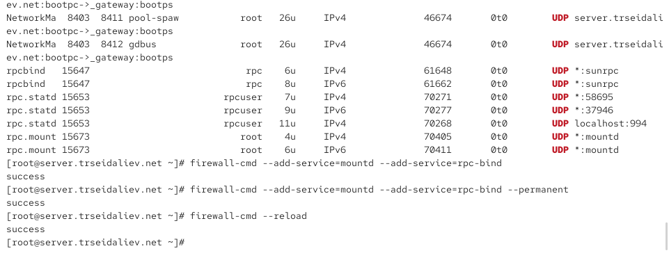

Просмотр служб TCP/UDP

## Разрешение служб

Разрешение необходимых сервисов в firewall даёт стабильный доступ NFS-клиента.

# Монтирование NFS на клиенте

## Ручное подключение

- Создание `/mnt/nfs`
- Монтирование ресурса `server:/srv/nfs`

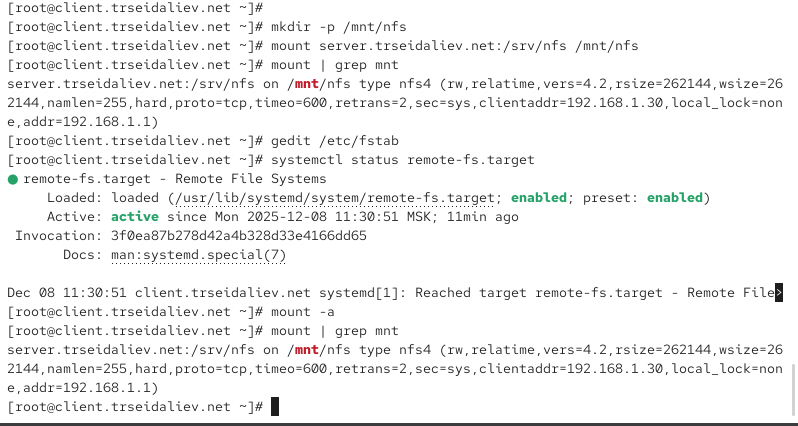

Монтирование /mnt/nfs

## Автоматическое подключение

Добавлена запись в `/etc/fstab`:

```
server.trseidaliev.net:/srv/nfs /mnt/nfs nfs _netdev 0 0
```

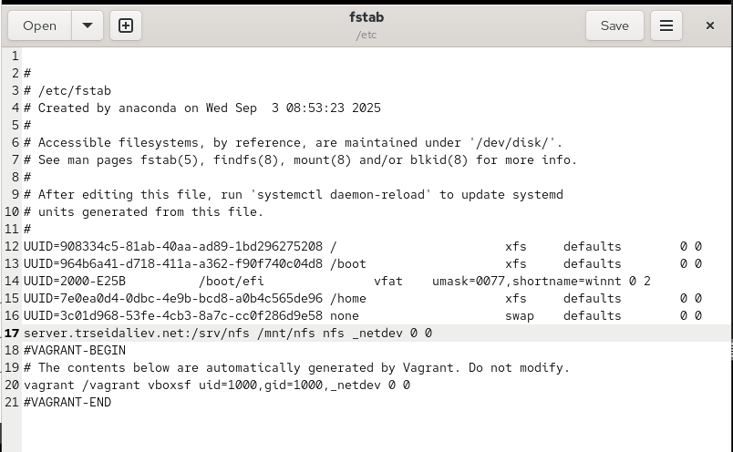

fstab клиента

# Экспорт веб-контента

## Подготовка каталога

- Создание `/srv/nfs/www`
- Bind-монтирование `/var/www`

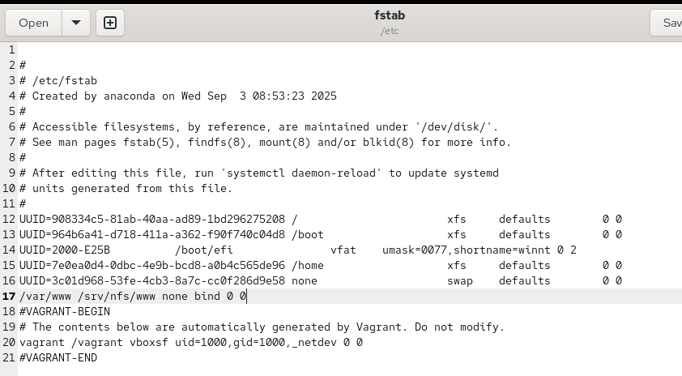

bind /var/www

## Экспорт каталога

Добавление в `/etc/exports`:

```
/srv/nfs/www 192.168.0.0/16(rw)
```

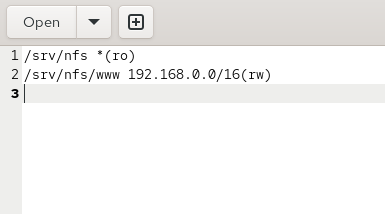

Экспорт www

# Проверка на клиенте

Каталог `www` появляется в `/mnt/nfs`.

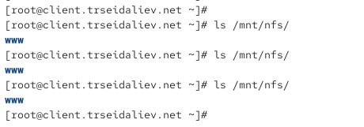

Каталог www на клиенте

# Пользовательские каталоги

## Создание каталога common

Пользователь создаёт каталог:

- `~/common`
- права доступа `700`
- файл `trseidaliev@server.txt`

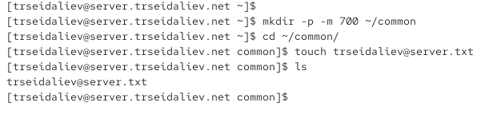

Каталог common

## Экспорт личного каталога

Добавление в `/etc/exports`:

```
/srv/nfs/home/trseidaliev 192.168.0.0/16(rw)
```

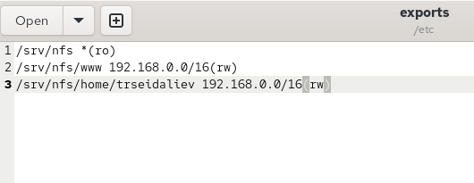

Экспорт пользовательского каталога

## Bind-монтирование и автозагрузка

Запись в `/etc/fstab`:

```
/home/trseidaliev/common /srv/nfs/home/trseidaliev none bind 0 0
```

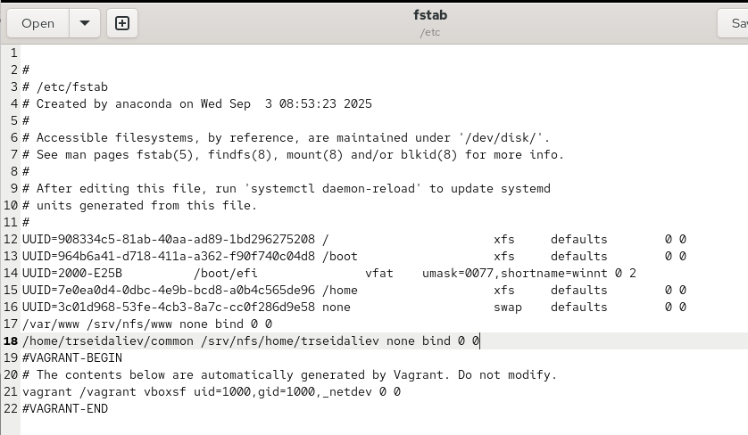

fstab с пользовательским каталогом

# Проверка работы пользователя на клиенте

## Пользовательские файлы

- Создание файла `trseidaliev@client.txt`
- Видны оба файла: от сервера и от клиента

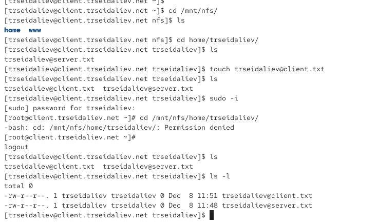

Работа с файлами пользователя

## Проверка на сервере

Каталог содержит оба файла:

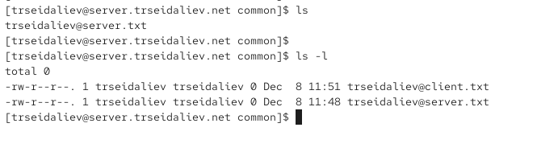

Проверка на сервере

# Итоги работы